# Corrélation et Régressions

CB

20 février 2020

# Bibliothèques et données

Les données sont un extrait de la base de l’ess. Elle rassemble les jugement de confiance à l’égards des institution et des personnes ( 10 items) en France et en allamenage, au cours de vagues d’enquêtes bisannuelles de l’Européan Social Survey. On dispose donc de données de 20014 à 2018. S’joutent quelques variables socio-démo : le pouvoir d’achat percu, l’age, le genre, l’orientation politique, le type d’habitat. On cherchera à examiner l’impact des conditions de vie du la confiance.

```r
knitr::opts_chunk$set(echo = TRUE, include=TRUE, cache=TRUE, message=FALSE, warning=FALSE)
library(tidyverse)
library(gridExtra)
library(reshape2)
library(ggridges)
library(stargazer)
library(jtools)

#lecture du fichier
df<-readRDS("mastermoi.rds")

#quelques recodages

#on renomme les items de confiance pour plus de clarte
names(df)[names(df)=="trstun"] <- "NationsUnies"
names(df)[names(df)=="trstep"] <- "ParlementEurop"
names(df)[names(df)=="trstlgl"] <- "Justice"
names(df)[names(df)=="trstplc"] <- "Police"
names(df)[names(df)=="trstplt"] <- "Politiques"
names(df)[names(df)=="trstprl"] <-"Parlement"
names(df)[names(df)=="trstprt"] <- "Partis"
names(df)[names(df)=="pplhlp"] <- "help"
names(df)[names(df)=="pplfair"] <- "fair"
names(df)[names(df)=="ppltrst"] <- "trust"

#recodage des variables indépendantes
df$Year[df$essround==1]<-2002
df$Year[df$essround==2]<-2004
df$Year[df$essround==3]<-2006
df$Year[df$essround==4]<-2008
df$Year[df$essround==5]<-2010
df$Year[df$essround==6]<-2012
df$Year[df$essround==7]<-2014
df$Year[df$essround==8]<-2016
df$Year[df$essround==9]<-2018
df$Year<-as.factor(df$Year)

df$cntry<-as.factor(df$cntry)

#on construit les scores de confiance
df<-df %>% mutate(trust_institution=(Partis+Parlement+Politiques+Police+Justice+NationsUnies+ParlementEurop)*10/7)

df<-df %>% mutate(trust_interpersonal=(help+fair+trust)*10/3)
```

# Un premier coup d’oeil sur les données

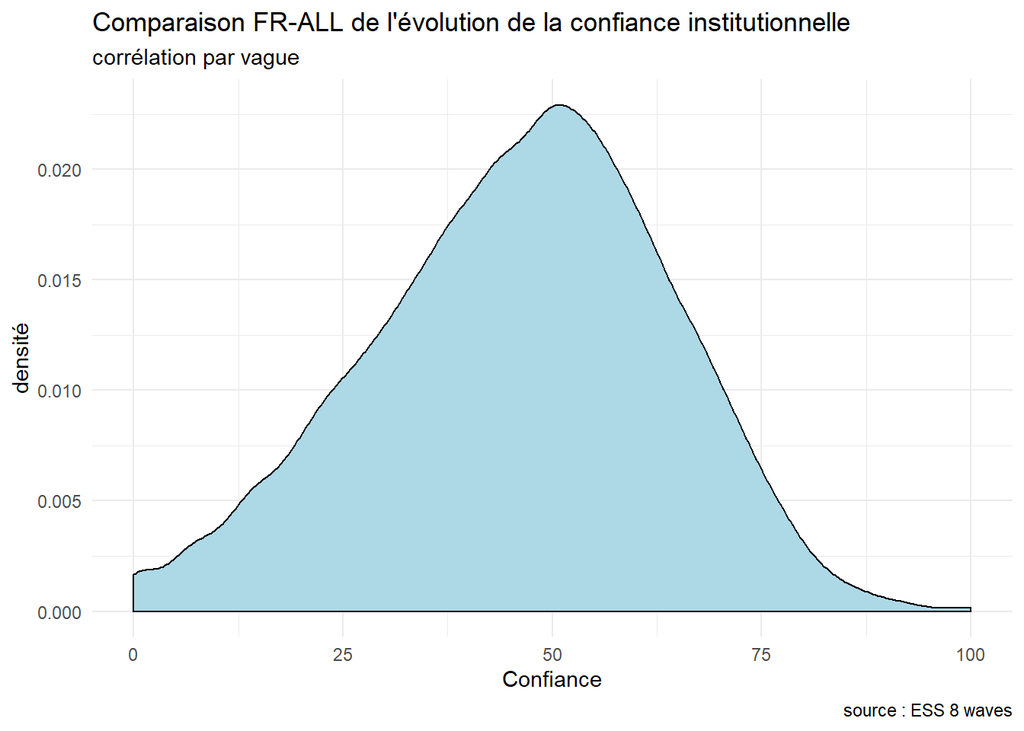

```r
hist<-df %>% dplyr::select(Year,cntry, trust_institution) %>% melt(id=c("cntry", "Year")) %>%filter(Year!="2002")

ggplot(df,aes(x=trust_institution))+geom_density(fill="lightblue")+
  theme_minimal()+
  labs(title = "Comparaison FR-ALL de l'évolution de la confiance institutionnelle",subtitle = "corrélation par vague" ,x = "Confiance", y="densité", caption="source : ESS 8 waves")
```

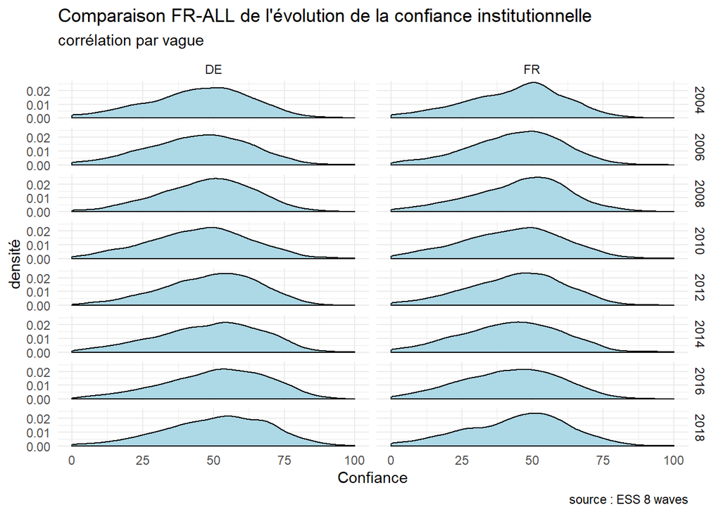

```r
hist<-df %>% dplyr::select(Year,cntry, trust_institution) %>%
  melt(id=c("cntry", "Year")) %>%filter(Year!="2002")
ggplot(hist,aes(x=value))+geom_density(fill="lightblue")+facet_grid(Year~cntry)+
  theme_minimal()+
  labs(title = "Comparaison FR-ALL de l'évolution de la confiance institutionnelle",subtitle = "corrélation par vague" ,x = "Confiance", y="densité", caption="source : ESS 8 waves")
```

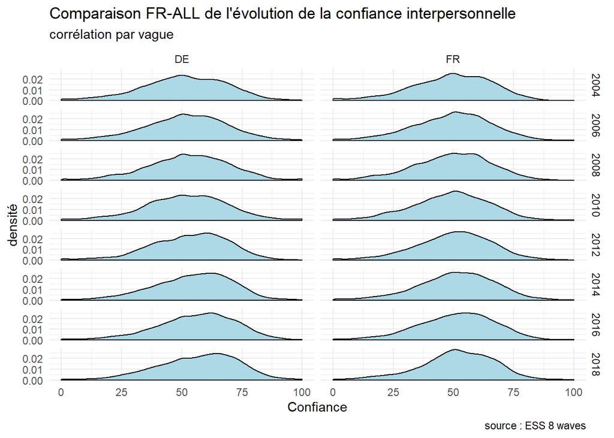

```r
hist<-df %>% dplyr::select(Year,cntry, trust_interpersonal) %>%
  melt(id=c("cntry", "Year")) %>%filter(Year!="2002")
ggplot(hist,aes(x=value))+geom_density(fill="lightblue")+facet_grid(Year~cntry)+
  theme_minimal()+
  labs(title = "Comparaison FR-ALL de l'évolution de la confiance interpersonnelle",subtitle = "corrélation par vague" ,x = "Confiance", y="densité", caption="source : ESS 8 waves")
```

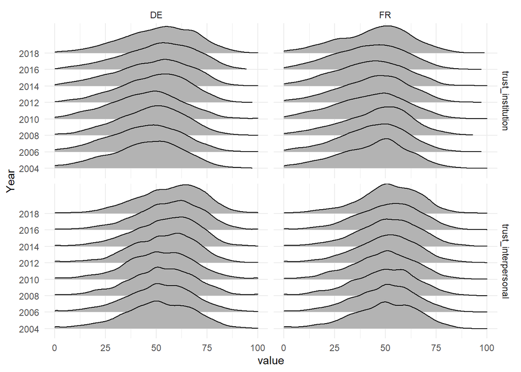

```r
#library(ggridges)

hist<-df %>% dplyr::select(Year,cntry, trust_institution, trust_interpersonal) %>%
  melt(id=c("cntry", "Year")) %>%filter(Year!="2002")

ggplot(hist, aes(value, Year, group = Year, height = ..density..)) +
  geom_density_ridges(stat = "density", trim = TRUE) + facet_grid((variable~cntry))+theme_minimal()
```

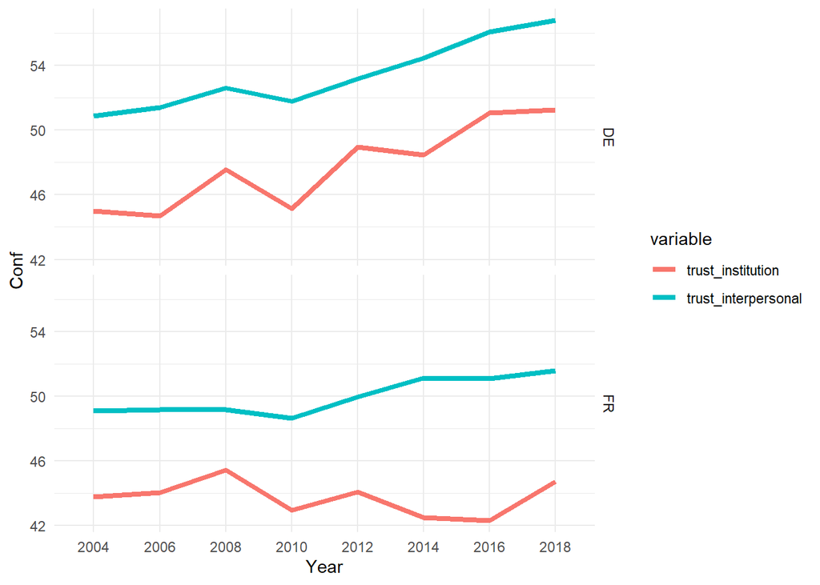

```r
foo<-hist %>% filter(!is.na(value)) %>% group_by(cntry,variable,Year) %>% dplyr::summarise(Conf=mean(value, na.rm=FALSE))

ggplot(foo, aes( x=Year, y=Conf, group = variable, group=cntry)) +geom_line(aes(color=variable), size=1.5) +theme_minimal()+ facet_grid(cntry~.)
```

# La corrélation entre les deux composantes de la confiance

On va faire un une analyse classique de correlation mais répété à travers les pays et les vagues d’enquêtes. Manifestement les corrélations sont stables dans le temps et les pays à une constante d’échelle et de paramètre près.

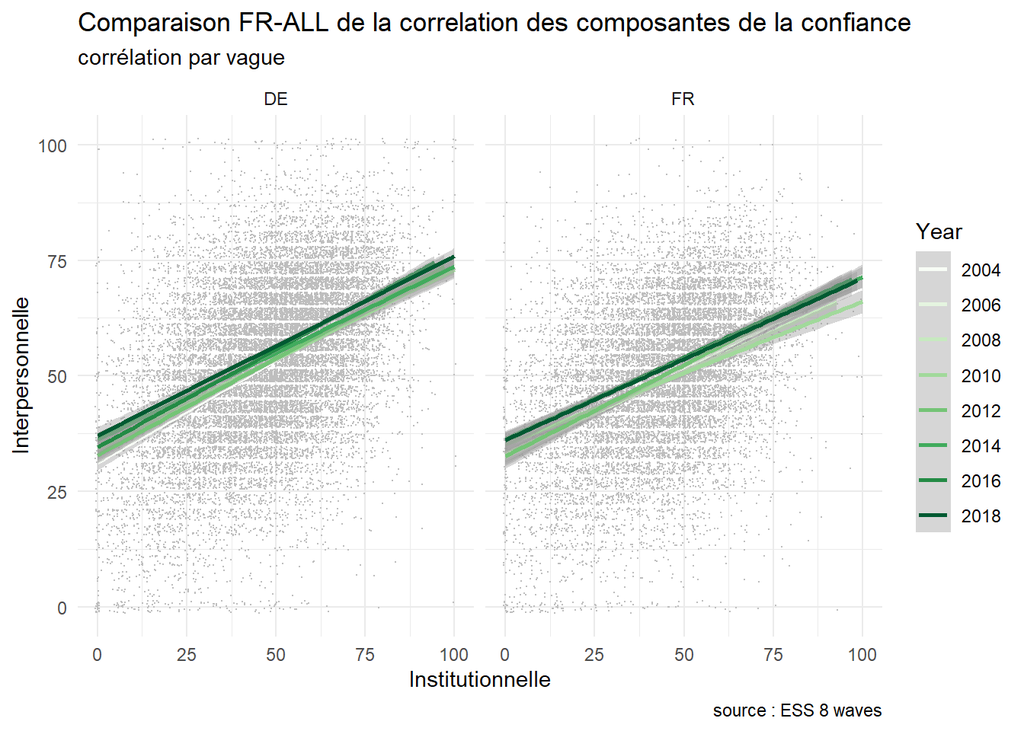

Pour mieux saisir les variation de corrélations, on peut vérifier en calculant les corrélations par année et par pays, et en les représentant graphiquement.

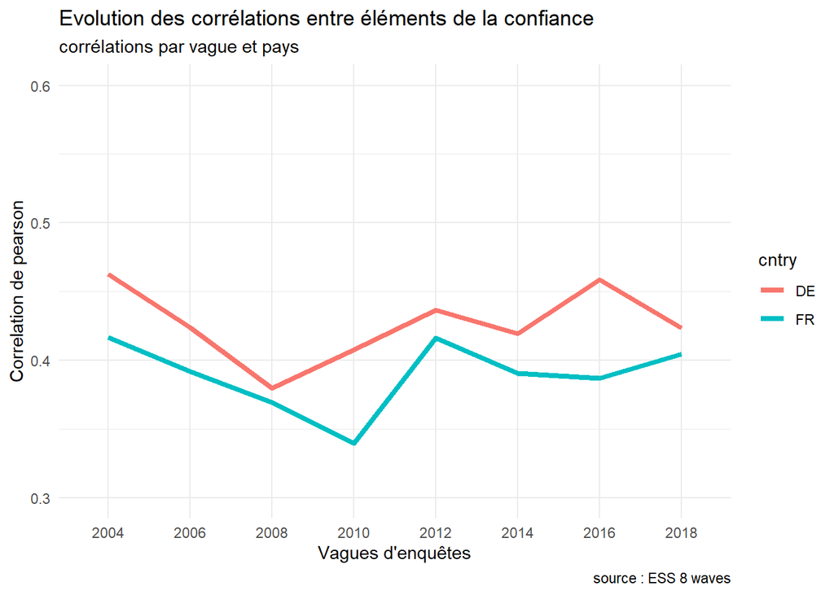

```r
library(corrplot)
df_cor <-df %>% dplyr::select(cntry,Year,trust_institution, trust_interpersonal) %>%filter(!is.na(trust_interpersonal) & !is.na(trust_institution))
library(plyr)
cor <- ddply(df_cor, c("Year","cntry"), summarise, corr=cor(trust_institution, trust_interpersonal))

ggplot(cor, aes(x=Year,y=corr,group=cntry))+geom_line(size=1.5,aes(color=cntry)) +
  theme_minimal()+ylim(0.3,0.6)+
  labs(title = "Evolution des corrélations entre éléments de la confiance",subtitle = "corrélations par vague et pays" ,x = "Vagues d'enquêtes", y="Correlation de pearson", caption="source : ESS 8 waves")
```

# corrélations multiples

nous avons raisonner sur la base d’une relation,on pourrait vouloir observer toutes les corrélations entre k variables. Regardons ce qui en est si on reprends les, items qui ont servi à construire les scores de satisfaction. On notera que c’est le point de départ d’une analyse factorielles.

On pourra chercher à représenter cette matrice pour les différents pays et vagues d’enquetes. Mais celà suffira.

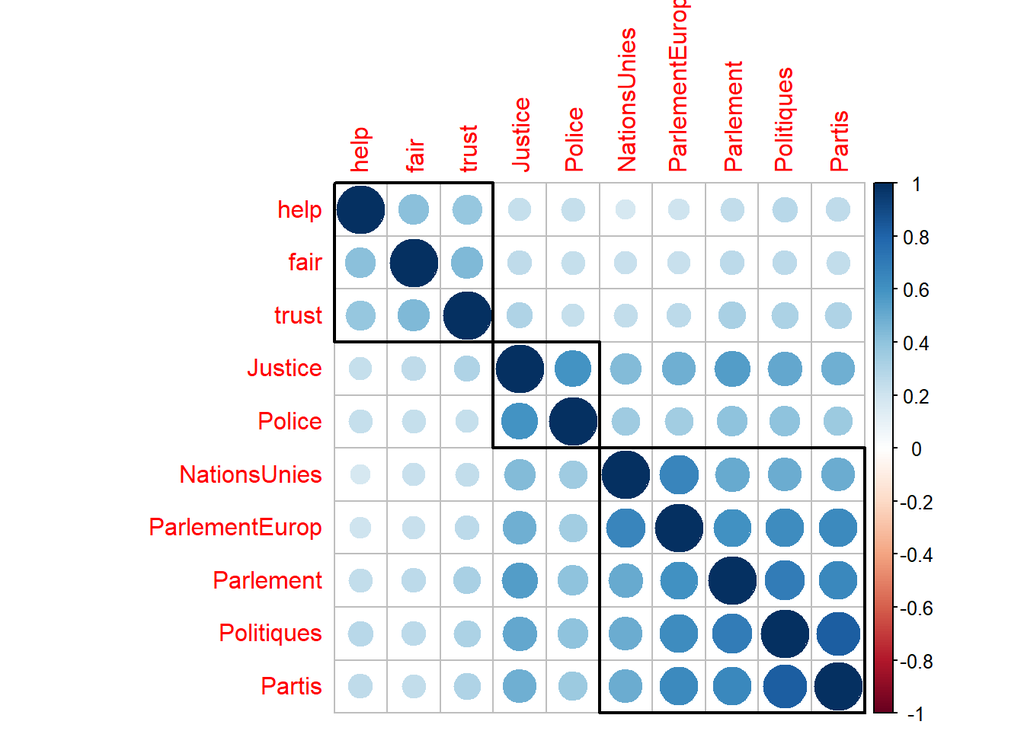

```r
library(corrplot)
M<-df %>% dplyr::select(help,fair,trust,NationsUnies,ParlementEurop,Justice, Police,Politiques,Parlement,Partis) %>% drop_na()
M<-cor(M)
corrplot(M, order = "hclust",addrect = 3)
```

# régression multiple

on va maintenant cercher à expliquer les différences entre les niveaux de confiances en fonction de quelques variables socio demo. Autrement dit construire un modèle du type :

y= a0+a1X1+a2X2+…+e

On va avoir besoin de recodage des variables explicatives.

```r
df$OP[df$lrscale==0] <- "Extrême gauche"
df$OP[df$lrscale==1] <- "Gauche"
df$OP[df$lrscale==2] <- "Gauche"
df$OP[df$lrscale==3] <- "Centre Gauche"
df$OP[df$lrscale==4] <- "Centre Gauche"
df$OP[df$lrscale==5] <- "Ni G ni D"
df$OP[df$lrscale==6] <- "Centre Droit"
df$OP[df$lrscale==7] <- "Centre Droit"
df$OP[df$lrscale==8] <- "Droite"
df$OP[df$lrscale==9] <- "Droite"
df$OP[df$lrscale==10] <- "Extrême droite"
#la ligne suivante est pour ordonner les modalités de la variables
df$OP<-factor(df$OP,levels=c("Extrême droite","Droite","Centre Droit","Ni G ni D","Centre Gauche","Gauche","Extrême gauche"))


df$revenu<-df$hincfel
df$revenu[df$hincfel>4] <- NA
df$revenu[df$hincfel==1] <- "Vie confortable"
df$revenu[df$hincfel==2] <- "Se débrouille avec son revenu"
df$revenu[df$hincfel==3] <- "Revenu insuffisant"
df$revenu[df$hincfel==4] <- "Revenu très insuffisant"
df$revenu<-factor(df$revenu,levels=c("Vie confortable","Se débrouille avec son revenu","Revenu insuffisant","Revenu très insuffisant"))

df$habitat[df$domicil==1]<- "Big city"
df$habitat[df$domicil==2]<-"Suburbs"
df$habitat[df$domicil==3]<-"Town"
df$habitat[df$domicil==4]<-"Village"
df$habitat[df$domicil==5]<-"Countryside"
df$habitat<-factor(df$habitat,levels=c("Big city","Suburbs","Town","Village","Countryside"))

df$genre[df$gndr==1]<-"H"
df$genre[df$gndr==2]<-"F"

df$age[df$agea<26]<-"25<"
df$age[df$agea>25 & df$agea<36]<-"26-35"
df$age[df$agea>35 & df$agea<46]<-"36-45"
df$age[df$agea>45 & df$agea<66]<-"46-65"
df$age[df$agea>65 & df$agea<76]<-"66-75"
df$age[df$agea>75]<-"75>"
df$age<-factor(df$age,levels=c("25<","26-35","36-45","46-65","66-75", "75>"))
```

```r
df_DE<-df %>% filter(cntry=="DE")
library(lme4)
fit00<-lm(trust_institution~age+genre+habitat+revenu+OP+trust_interpersonal+Year, data=df_DE)
summary(fit00)
```

```
##
## Call:
## lm(formula = trust_institution ~ age + genre + habitat + revenu +
##     OP + trust_interpersonal + Year, data = df_DE)
##
## Residuals:
## <Labelled double>: Trust in political parties
##     Min      1Q  Median      3Q     Max
## -66.972 -10.192   0.660  10.659  79.508
##
## Labels:
##  value           label
##      0 No trust at all
##      1               1
##      2               2
##      3               3
##      4               4
##      5               5
##      6               6
##      7               7
##      8               8
##      9               9
##     10  Complete trust
##     77         Refusal
##     88      Don't know
##     99       No answer
##
## Coefficients:
##                                      Estimate Std. Error t value Pr(>|t|)
## (Intercept)                         31.021655   1.255821  24.702  < 2e-16 ***
## age26-35                            -3.802856   0.434569  -8.751  < 2e-16 ***
## age36-45                            -4.766877   0.410709 -11.606  < 2e-16 ***
## age46-65                            -6.758909   0.354618 -19.060  < 2e-16 ***
## age66-75                            -7.104649   0.434055 -16.368  < 2e-16 ***
## age75>                              -5.752892   0.536100 -10.731  < 2e-16 ***
## genreH                               0.450817   0.223887   2.014 0.044067 *
## habitatSuburbs                      -0.383885   0.406355  -0.945 0.344823
## habitatTown                         -0.991763   0.327765  -3.026 0.002483 **
## habitatVillage                      -1.870934   0.342243  -5.467 4.64e-08 ***
## habitatCountryside                  -2.283695   0.844811  -2.703 0.006874 **
```

[output cut: 9 more lines]

```
## trust_interpersonal                  0.407524   0.006862  59.388  < 2e-16 ***
## Year2006                            -0.449703   0.457666  -0.983 0.325816
## Year2008                             1.811007   0.458697   3.948 7.90e-05 ***
## Year2010                            -0.573590   0.449150  -1.277 0.201598
## Year2012                             2.729743   0.446258   6.117 9.72e-10 ***
## Year2014                             1.694438   0.440538   3.846 0.000120 ***
## Year2016                             2.946782   0.447458   6.586 4.65e-11 ***
## Year2018                             3.081185   0.470080   6.555 5.72e-11 ***
## ---
## Signif. codes:  0 '***' 0.001 '**' 0.01 '*' 0.05 '.' 0.1 ' ' 1
##
## Residual standard error: 15.42 on 19295 degrees of freedom
##   (6377 observations deleted due to missingness)
## Multiple R-squared:  0.2388, Adjusted R-squared:  0.2377
## F-statistic: 224.1 on 27 and 19295 DF,  p-value: < 2.2e-16
```

```r
fit01<-lm(trust_interpersonal~age+genre+habitat+revenu+OP+trust_institution+ Year, data=df_DE)

df_FR<-df %>% filter(cntry=="FR")
fit02<-lm(trust_institution~age+genre+habitat+revenu+OP+trust_interpersonal+Year, data=df_FR)
fit03<-lm(trust_interpersonal~age+genre+habitat+revenu+OP+trust_institution+ Year, data=df_FR)
```

On peut faire plus plus joli avec summ en produisant un diagramme des effets, le premier est général le second particulier. On utilise pour celà des fonctions du package `jtools`. https://cran.r-project.org/web/packages/jtools/vignettes/summ.html

```r
#library(jtools)
export_summs(fit00,scale = TRUE)
```

|  | Model 1 |
| --- | --- |
| (Intercept) | 52.94 *** |
|  | (1.20) |
| age26-35 | -3.80 *** |
|  | (0.43) |
| age36-45 | -4.77 *** |
|  | (0.41) |
| age46-65 | -6.76 *** |
|  | (0.35) |
| age66-75 | -7.10 *** |
|  | (0.43) |
| age75> | -5.75 *** |
|  | (0.54) |
| genreH | 0.45 * |
|  | (0.22) |
| habitatSuburbs | -0.38 |
|  | (0.41) |
| habitatTown | -0.99 ** |
|  | (0.33) |
| habitatVillage | -1.87 *** |
|  | (0.34) |
| habitatCountryside | -2.28 ** |
|  | (0.84) |
| revenuSe débrouille avec son revenu | -3.55 *** |
|  | (0.25) |
| revenuRevenu insuffisant | -6.66 *** |
|  | (0.41) |
| revenuRevenu très insuffisant | -9.19 *** |
|  | (0.68) |
| OPDroite | 1.97 |
|  | (1.20) |
| OPCentre Droit | 4.00 *** |
|  | (1.11) |
| OPNi G ni D | 1.94 |
|  | (1.09) |
| OPCentre Gauche | 3.39 ** |
|  | (1.09) |
| OPGauche | 0.71 |
|  | (1.13) |
| OPExtrême gauche | -2.75 * |
|  | (1.22) |
| trust_interpersonal | 6.85 *** |
|  | (0.12) |
| Year2006 | -0.45 |
|  | (0.46) |
| Year2008 | 1.81 *** |
|  | (0.46) |
| Year2010 | -0.57 |
|  | (0.45) |
| Year2012 | 2.73 *** |
|  | (0.45) |
| Year2014 | 1.69 *** |
|  | (0.44) |
| Year2016 | 2.95 *** |
|  | (0.45) |
| Year2018 | 3.08 *** |
|  | (0.47) |
| N | 19323 |
| R2 | 0.24 |
| *** p < 0.001; ** p < 0.01; * p < 0.05. |  |

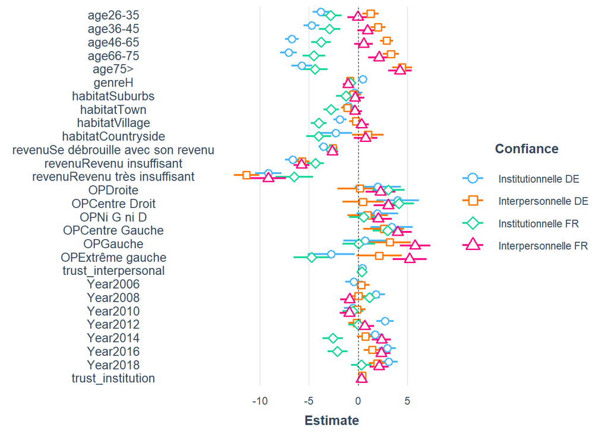

```r
plot_summs(fit00,fit01,fit02,fit03, scale = FALSE ,model.names = c("Institutionnelle DE", "Interpersonnelle DE", "Institutionnelle FR", "Interpersonnelle FR"), legend.title="Confiance")
```

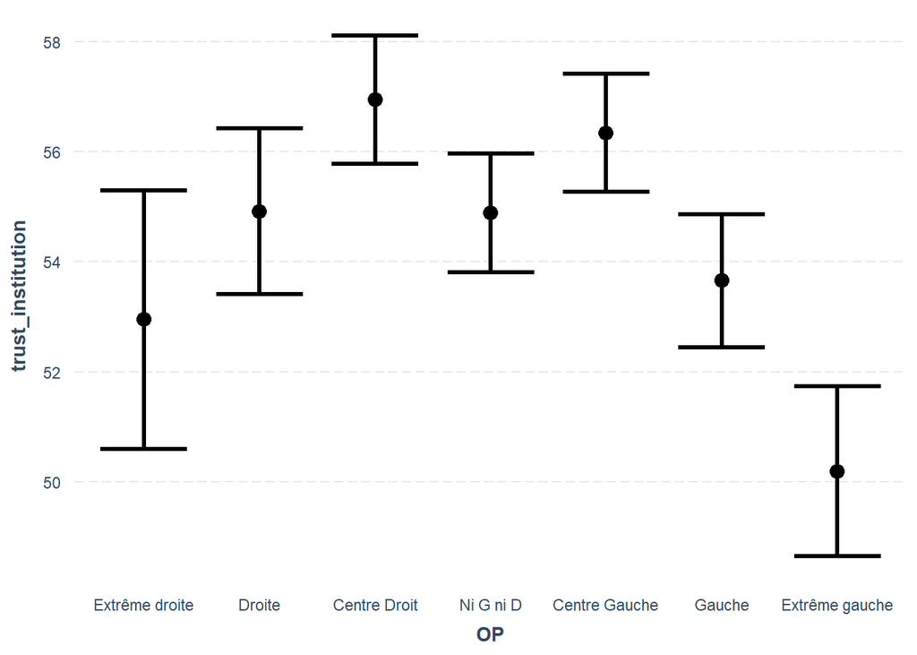

```r
effect_plot(fit00, pred = OP, interval = TRUE, plot.points = FALSE)
```

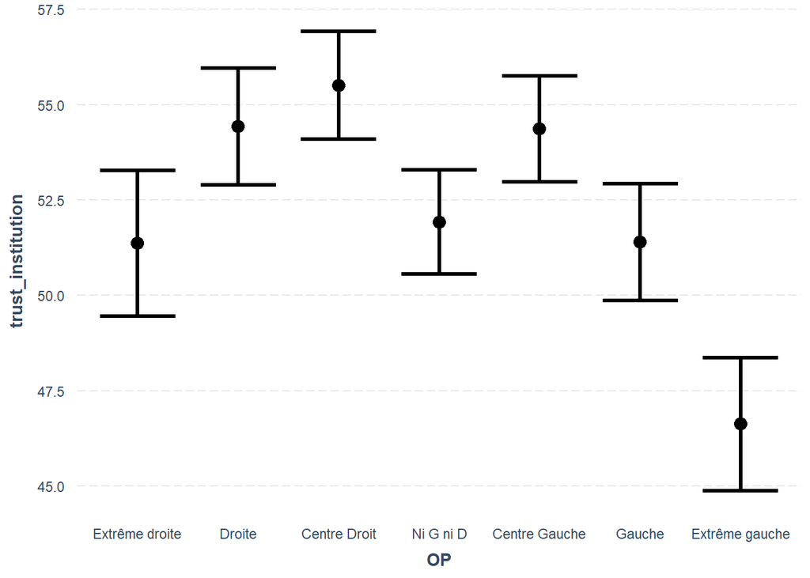

```r
effect_plot(fit02, pred = OP, interval = TRUE, plot.points = FALSE)
```

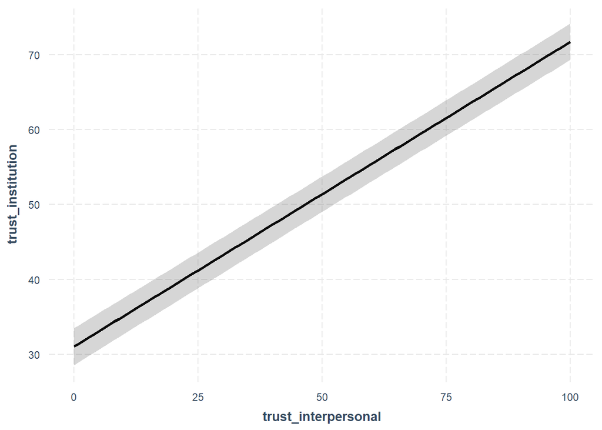

```r
effect_plot(fit00, pred = trust_interpersonal, interval = TRUE, plot.points = FALSE)
```

https://cran.r-project.org/web/packages/jtools/vignettes/summ.html